# Question

Para ambientar musicalmente una reunión, se cuenta con tres CDs, cada uno de ellos tiene canciones de salsa (S) y merengue (M). ¿Cuál de los siguientes diagramas representa la situación de seleccionar al azar una canción del CD1, luego una del CD2 y finalmente una del CD3?

**Opción A:**

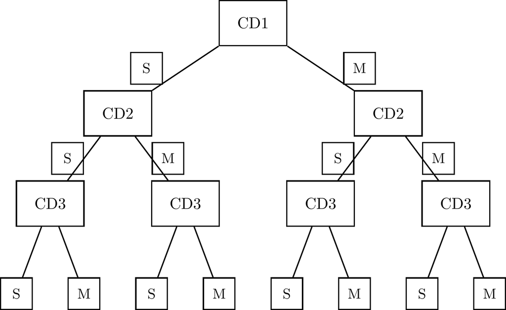

**Opción B:**

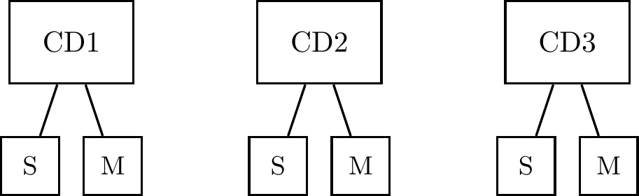

**Opción C:**

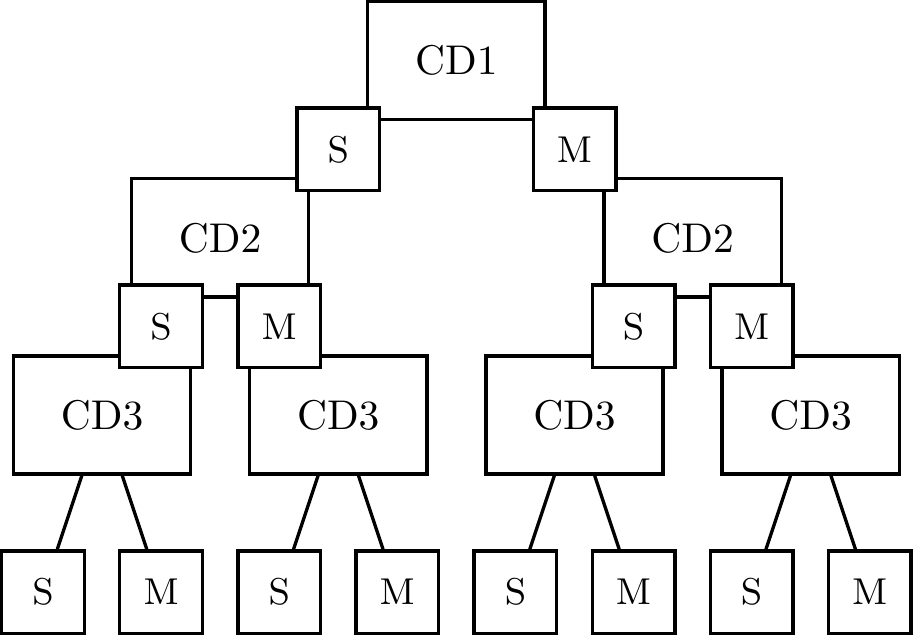

**Opción D (CORRECTA):**

[figure not shown]

## Answerlist

- Opción A
- Opción B
- Opción C
- Opción D

# Solution

**Diagrama correcto: Opción D**

El diagrama debe representar la **secuencia de decisiones** al seleccionar una canción de cada CD en orden: primero del CD1, luego del CD2, y finalmente del CD3.

**Estructura correcta (Opción D):**

1. **CD1** (inicio): 1 nodo que se ramifica en 2 opciones (S o M)
2. **CD2** (segundo nivel): 2 nodos, uno por cada rama de CD1, cada uno se ramifica en 2 opciones → 4 ramas totales
3. **CD3** (tercer nivel): 4 nodos, uno por cada rama de CD2, cada uno se ramifica en 2 opciones → **8 resultados finales**

**Total de combinaciones:** 2 × 2 × 2 = **8 combinaciones posibles**

Las 8 combinaciones son: - S-S-S - S-S-M - S-M-S - S-M-M - M-S-S - M-S-M - M-M-S - M-M-M

**Análisis de opciones incorrectas:**

- **Opción A:** Aunque tiene la estructura de árbol correcta con 8 resultados, la disposición **vertical** dificulta la lectura de la secuencia temporal CD1→CD2→CD3. Es funcionalmente correcta pero visualmente confusa.
- **Opción B:** ERROR GRAVE - Muestra CD1, CD2 y CD3 como decisiones **independientes y paralelas**, no como una secuencia. Solo genera 6 resultados (2+2+2) en lugar de 8 (2×2×2).
- **Opción C:** Tiene la estructura secuencial correcta y genera las 8 combinaciones, pero la disposición vertical hace que sea menos clara que la opción D para visualizar la secuencia.

**¿Por qué D es superior?**

La disposición **horizontal de izquierda a derecha** en la opción D facilita: - Visualizar la secuencia temporal (primero CD1, luego CD2, luego CD3) - Contar las ramificaciones en cada nivel - Identificar las 8 combinaciones finales

**Principio clave:** En un proceso secuencial de selección, cada etapa debe representarse como un nivel en el árbol, y la disposición visual debe facilitar la comprensión del orden temporal.

## Answerlist

- Falso
- Falso
- Falso
- Verdadero

# Meta-information

extype: schoice exsolution: 0001 exname: diagrama_arbol_seleccion_canciones exshuffle: FALSE